# Презентация по лабораторной работе 4

Иммитационное моделирование

Нджову Нелиа

1032239033@rudn.ru

Российский университет дружбы народов

## Цель работы

Цель этой лабораторной работы использовать агентную модель для моделирования SIR модель.

## Задание

1. Базовый уровень

— Запустите модель с параметрами по умолчанию. — Постройте график динамики численности S, I, R. — Определите базовое репродуктивное число $R_0$ по формуле $R_0 = \frac{\beta}{\gamma}$, где $\gamma = \frac{1}{infection_period}$ — Сравните с наблюдаемой динамикой.

2. Исследование порога

— Найдите минимальное значение $\beta$, при котором возникает эпидемия (пик I > 5% популяции). — Сравните с теоретическим порогом $R_0 = 1.$

3. Эффект гетерогенности

— Задайте разные значения $\beta$ для разных городов. — Как это влияет на общую динамику? — Постройте графики для каждого города отдельно.

## Задание

4. Миграция

— Исследуйте влияние интенсивности миграции на скорость распространения инфекции из одного города в другие. — При какой интенсивности время до пика минимально?

5. Карантинные меры — Модифицируйте модель, добавив возможность закрытия города (обнуление миграции из него) при превышении порога заболеваемости. — Оцените эффективность такой меры.
6. Оптимизация — Используя оптимизацию, найдите параметры, которые минимизируют общее число умерших при сохранении пика заболеваемости ниже 30%.

## Классическая модель SIR

Модель SIR, предложенная Кермаком и Маккендриком в 1927 году, описывает динамику эпидемии в популяции, разделённой на три группы:

— S (Susceptible) — восприимчивые к заболеванию индивиды; — I (Infectious) — инфицированные, способные заражать восприимчивых; — R (Recovered) — выздоровевшие (или умершие), получившие иммунитет и более не участвующие в распространении.

## Классическая модель SIR

Классическая модель описывается системой обыкновенных дифференциальных уравнений:

$$\frac{ds}{dt} = \frac{\beta*S*I}{N},
\frac{dI}{dt} = \frac{\beta*S*I}{N - \gamma*I},
\frac{dR}{dt} = \gamma*I$$

где $\beta$ — коэффициент передачи инфекции, $\gamma$ — скорость выздоровления.

Ограничения классического подхода: Однородность популяции, Отсутствие пространственной структуры, Детерминированность и Непрерывность

Преимущества агентного подхода: Агентное моделирование позволяет преодолеть эти ограничения:

— Каждый индивид моделируется отдельно с уникальными характеристиками. — Взаимодействия происходят локально в пространстве или социальной сети. — Процессы носят стохастический характер. — Можно учитывать гетерогенность контактов, мобильность, меры контроля.

## Агенты

Каждый агент — человек, обладающий следующими свойствами:

— status::Symbol — состояние (:S, :I, :R); — days_infected::Int — количество дней с момента заражения (для инфицированных).

## Пространство состояний

Агенты размещаются на графе, где узлы представляют локации (города, районы), а рёбра — возможные перемещения между ними. Такой подход позволяет моделировать метапопуляционную динамику и миграцию.

*Параметры модели*

— Ns — вектор численности населения по локациям; — $/beta$_und — вероятность передачи для невыявленных случаев; — $/beta$_det — вероятность передачи для выявленных случаев; — infection_period — длительность заболевания (дней); — detection_time — время до выявления заболевания; — death_rate — вероятность летального исхода; — reinfection_probability — вероятность повторного заражения; — migration_rates — матрица вероятностей миграции между локациями.

## Динамика

На каждом шаге (соответствует одному дню) для каждого агента выполняются следующие процессы:

— Миграция — агент может переместиться в другую локацию с вероятностью, заданной матрицей migration_rates. — Передача инфекции — если агент инфицирован, он может заразить восприимчивых агентов в той же локации. Количество заражённых за день определяется пуассоновским процессом с интенсивностью, зависящей от статуса выявления ($\beta$_und или $\beta$_det). — Обновление счётчика — для инфицированных увеличивается days_infected. — Выздоровление или смерть — если days_infected достиг infection_period, агент либо выздоравливает (переходит в R), либо умирает (удаляется из модели) с вероятностью death_rate. Выздоровевшие могут быть повторно инфицированы с вероятностью reinfection_probability.

## 1. Базовый уровень

Я создала файл sir_model.jl и копировала в него скрипт из лабораторного руководства. скрипт определяет основную модель SIR (агенты, распространение болезней, миграция, выздоровление и смерть), которую все сценарии эксперимента используют в качестве механизма моделирования. Я запускаю его, и все работает идеально(рис.1).

## 1. Базовый уровень

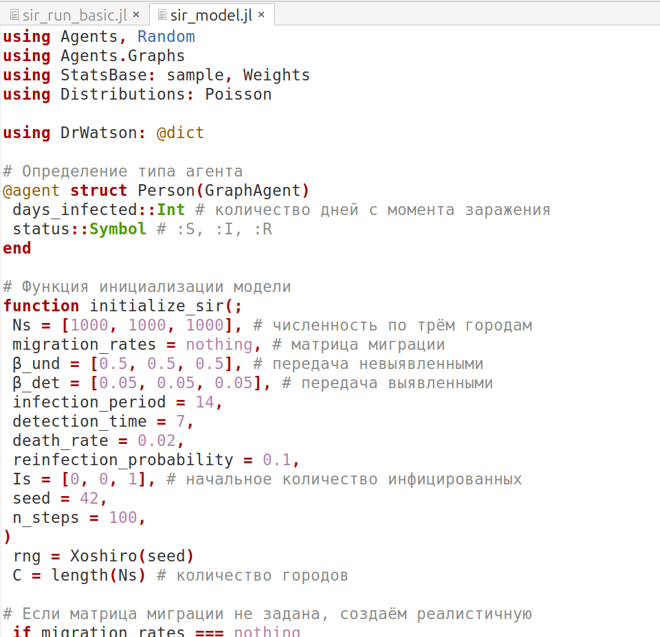

Рисунок 1: Основной модель SIR

## 1. Базовый уровень

Я создала файл sir_run_basic.jl и копирую в него скрипт из лабораторного руководства. Скрипт запускает один эксперимент с фиксированными параметрами (по умолчанию) и сохраняет динамику численности агентов. Это служит для проверки работоспособности модели и получения базового понимания эпидемического процесса.(рис.2)

## 1. Базовый уровень

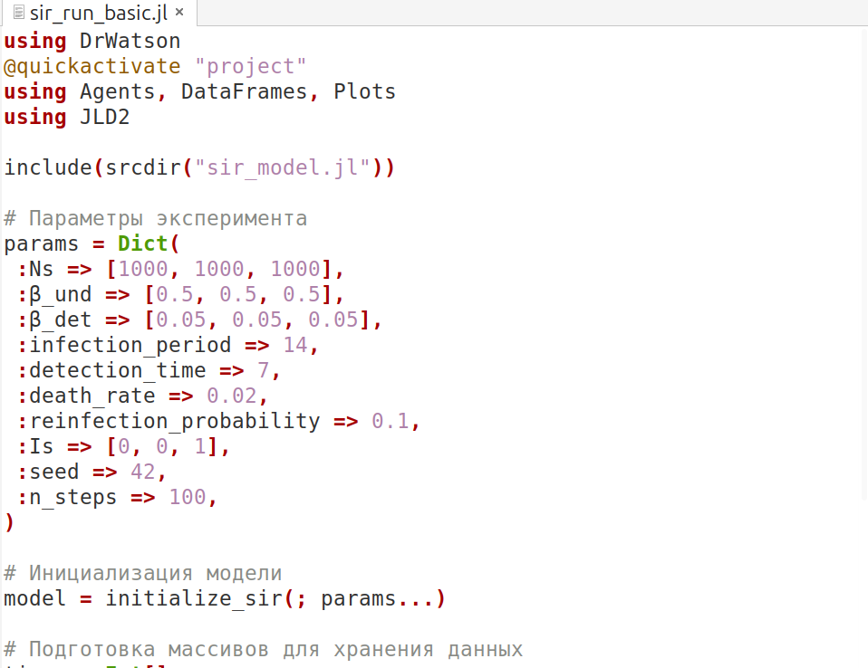

Рисунок 2: Базовый эксперимент

## 1. Базовый уровень

Я преобразую код в литературный стиль(рис.3)

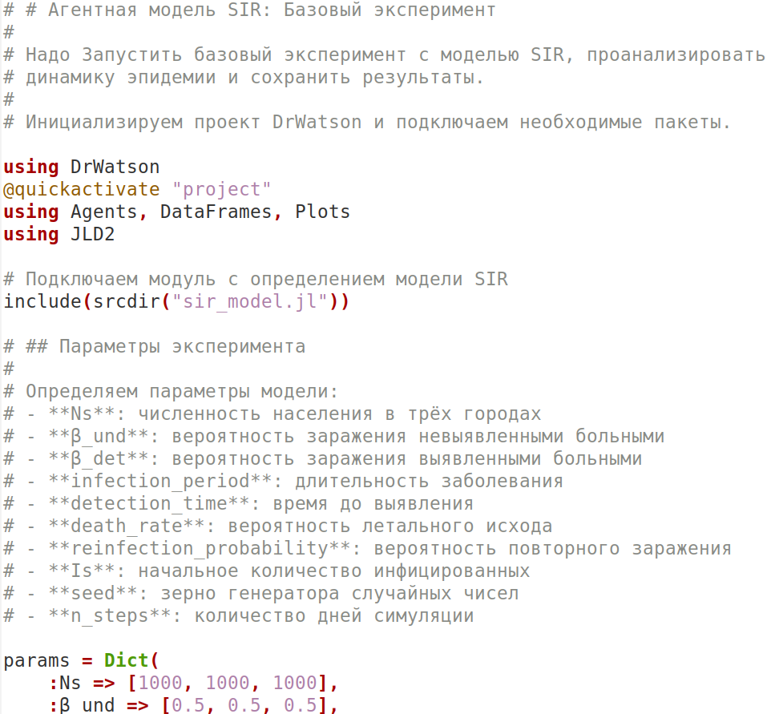

Рисунок 3: Литературный стиль

## 1. Базовый уровень

Я запустила его, и все заработало, я получила график ниже. На графике мы можем видеть, как работает модель sir: сначала инфицированных людей нет, но с течением времени заболевает все больше и больше людей, пока все они не будут инфицированы, некоторые не вылечатся, а другие не умрут(рис.4)

## 1. Базовый уровень

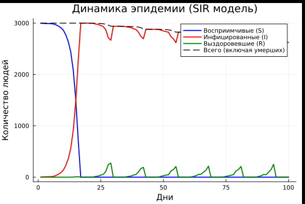

Рисунок 4: График модель SIR

## 1. Базовый уровень

После этого я создала текст на основе литературного кода: чистого кода, записной книжки jupyter и документации в формате Quarto. Я запускала все ячейки в файле jupyter notebook, и все работает хорошо(рис.5)

[figure not shown]

Рисунок 5: создание файлов

## 1. Базовый уровень

Я добавляю код для определения базового репродуктивного числа $R_0$ по формуле $R_0 = \frac{\beta}{\gamma}$, где $\gamma = {1}{infection_period}$(рис.6)

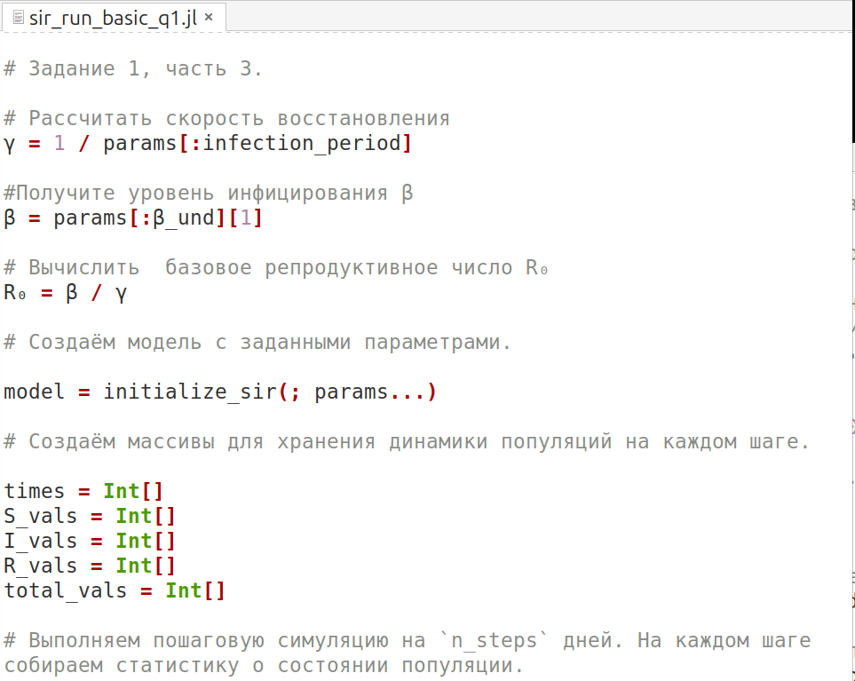

Рисунок 6: Базовое репродуктивное число

## 1. Базовый уровень

Результат для базового репродуктивного числа $R_0$ равен 7,0. Это означает, что один инфицированный человек заразит в среднем еще 7 человек из полностью восприимчивой популяции(рис.7)

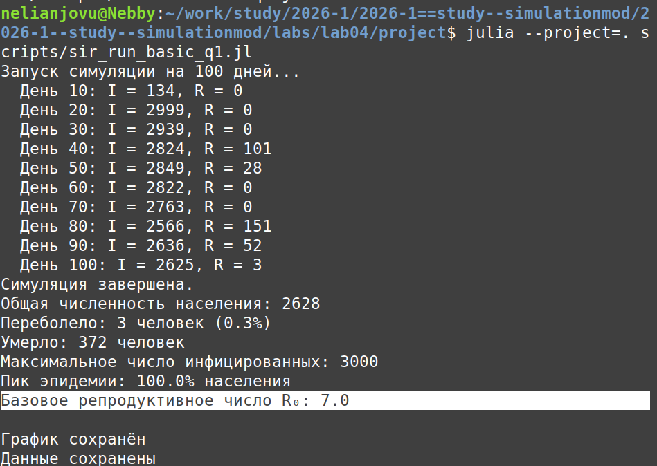

Рисунок 7: Базовое репродуктивное число

## 1. Базовый уровень

После этого я создала текст на основе литературного кода: чистого кода, записной книжки jupyter и документации в формате Quarto. Я запускала все ячейки в файле jupyter notebook, и все работает хорошо(рис.8)

[figure not shown]

Рисунок 8: создание файлов

## 1. Базовый уровень

Наблюдаемая динамика соответствует теоретическим ожиданиям. R₀ = 7 > 1 предсказывает крупную эпидемию, и моделирование показывает, что заражается почти все население. Пик эпидемии наступает быстро (17 дней), что характерно для высококонтагиозных заболеваний(рис.9)

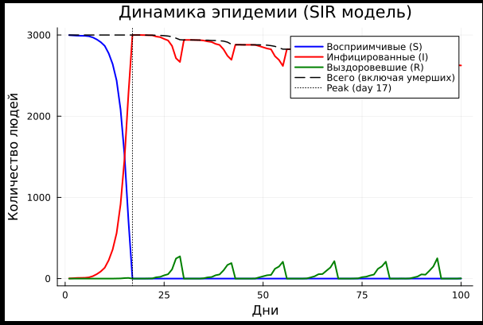

Рисунок 9: Наблюдаемая динамика

## 2. Исследование порога

Я создала файл sir_scan_beta.jl и копирую в него скрипт из лабораторного руководства. Скрипт исследует, как изменение базовой заразности ($\beta$_und и пропорционально $\beta$_det) влияет на эпидемические показатели: пик заболеваемости, долю переболевших, число умерших. Выполняется параметрическое сканирование с несколькими повторными прогонами для учёта стохастичности(рис.9)

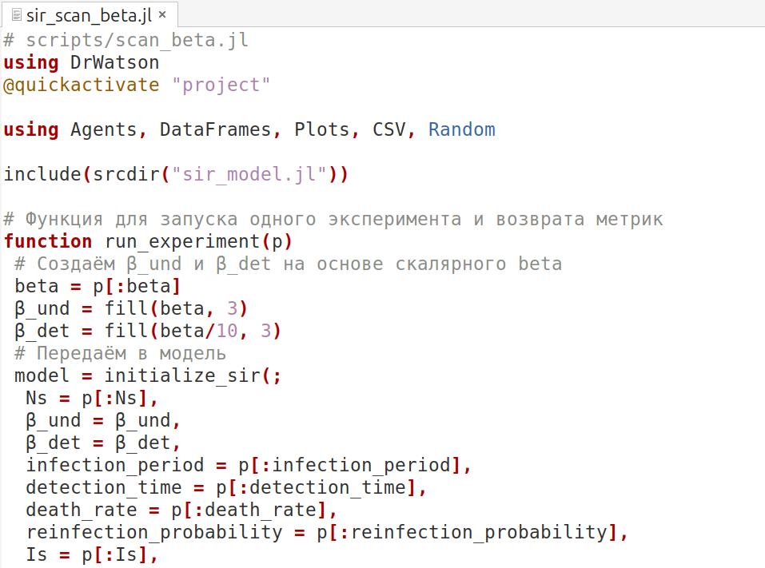

Рисунок 10: коэффициент заразности

## 2. Исследование порога

Я преобразую код в литературный стиль(рис.10)

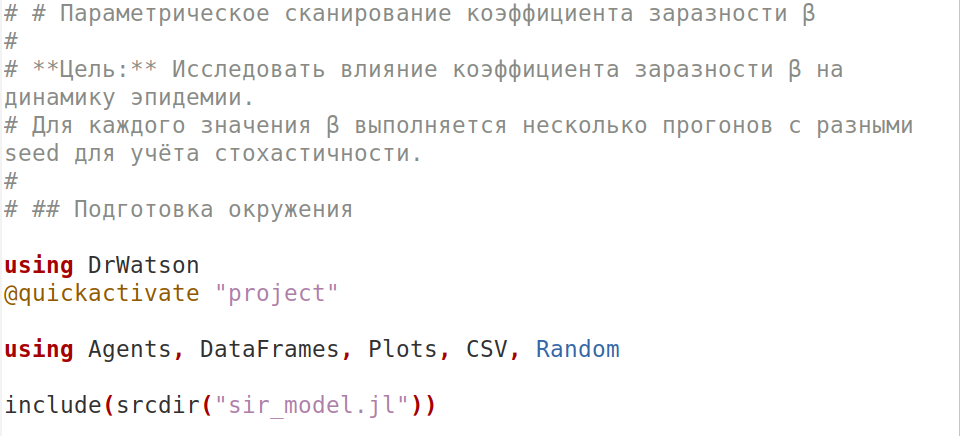

Рисунок 11: Литературный стиль

## 2. Исследование порога

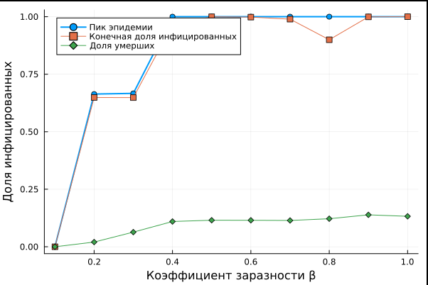

Рисунок 12: График

## 2. Исследование порога

После этого я создала текст на основе литературного кода: чистого кода, записной книжки jupyter и документации в формате Quarto. Я запускала все ячейки в файле jupyter notebook, и все работает хорошо(рис.12)

[figure not shown]

Рисунок 13: создание файлов

## 2. Исследование порога

Я добавляю код, чтобы найти минимальное значение $\beta$, при котором возникает эпидемия (пик I > 5% населения)(рис.13)

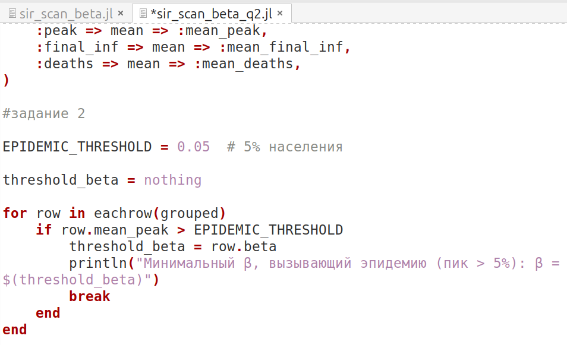

Рисунок 14: минимальное значение $\beta$

## 2. Исследование порога

Теоретический порог ($\beta$ = 0,071) ниже, чем то, что показывает моделирование ($\beta$ ≈ 0,2). Это связано с тем, что: Стохастические эффекты (случайный шанс) - при первичном заражении только 1 человека инфекция может прекратиться, даже если $R_0$ > 1. Небольшое население (3000 человек) - дискретные эффекты имеют значение. Пространственная структура - 3 города, заражение начинается только в 1 городе. Таким образом, моделирование показывает более высокий эффективный порог, чем предсказывает математическая теория.(рис.14)

## 2. Исследование порога

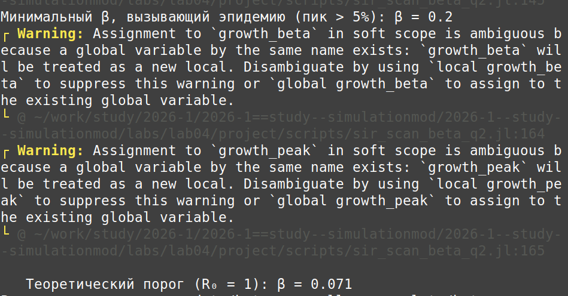

Рисунок 15: минимальное значение $\beta$

## 2. Исследование порога

После этого я создала текст на основе литературного кода: чистого кода, записной книжки jupyter и документации в формате Quarto. Я запускала все ячейки в файле jupyter notebook, и все работает хорошо(рис.15)

[figure not shown]

Рисунок 16: создание файлов

## 3. Эффект гетерогенности

Я установила разные значения для $\beta$ для разных городов(рис.16)

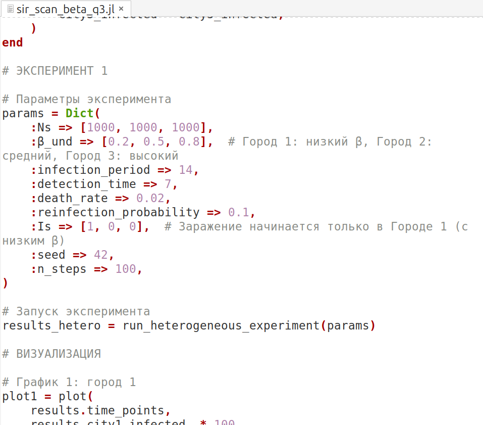

Рисунок 17: разные значения для $\beta$

## 3. Эффект гетерогенности

Неоднородность $\beta$ влияет на скорость распространения эпидемии. Когда заражение начинается в городе с высоким $\beta$ (0,8), эпидемия распространяется быстрее: пик приходится на 15-16-й день, а город с высоким $/beta$ достигает максимума раньше других. Когда инфекция начинается в городе с низким $\beta$ (0,2), распространение замедляется: все города достигают пика одновременно только на 23-й день. Таким образом, чем выше $\beta$ в городе, где начинается инфекция, тем быстрее эпидемия охватывает все население(рис.17;18;19;20;21 и 22)

## 3. Эффект гетерогенности

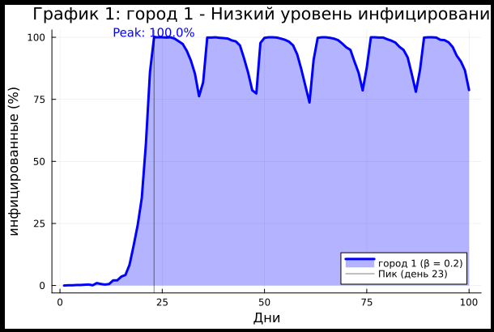

Рисунок 18: Город 1($\beta = 0.2$): Пик(день 23)

## 3. Эффект гетерогенности

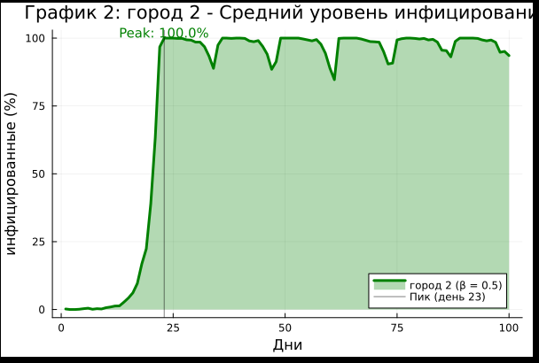

Рисунок 19: Город 2($\beta = 0.5$): Пик(день 23)

## 3. Эффект гетерогенности

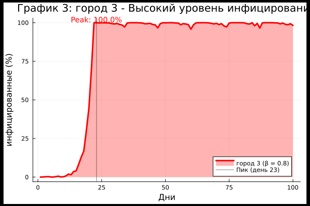

Рисунок 20: Город 3($\beta = 0.8$): Пик(день 23)

## 3. Эффект гетерогенности

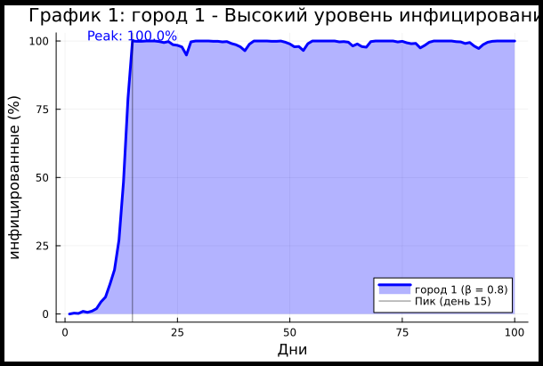

Рисунок 21: Город 1($\beta = 0.8$): Пик(день 15)

## 3. Эффект гетерогенности

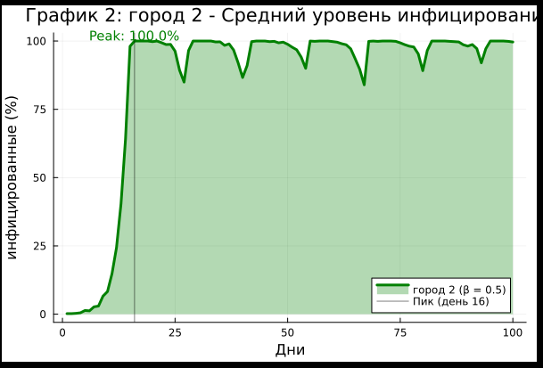

Рисунок 22: Город 2($\beta = 0.5$): Пик(день 16)

## 3. Эффект гетерогенности

[figure not shown]

## 4. Миграция

Я создала файл sir_migration_effect.jl и копирую в него скрипт из лабораторного руководства. Скрипт исследует, как интенсивность перемещения людей между городами влияет на скорость распространения эпидемии (время достижения пика) и масштаб пика. Инфекция начинается только в одном городе, остальные изначально здоровы. Я преобразовала код в литературный стиль(рис.23)

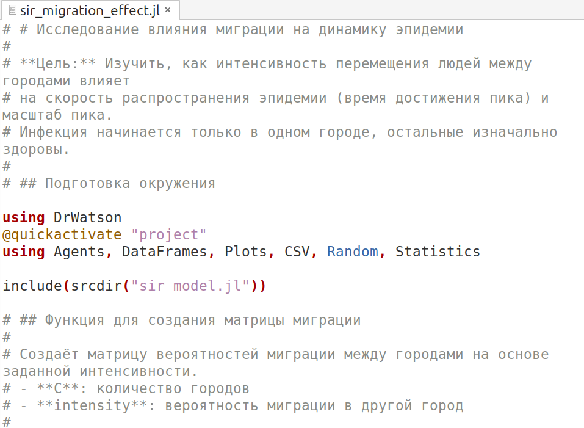

Рисунок 24: Исследование эффекта миграции

## 4. Миграция

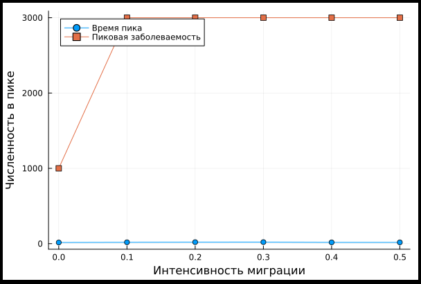

Рисунок 25: График

## 4. Миграция

После этого я создала текст на основе литературного кода: чистого кода, записной книжки jupyter и документации в формате Quarto. Я запускала все ячейки в файле jupyter notebook, и все работает хорошо(рис.25)

[figure not shown]

Рисунок 26: создание файлов

## 4. Миграция

При отсутствии миграции (0,0) пик заболеваемости наступает рано, но заболевает только 33,3% населения (только жители того города, где началось заражение). При высокой миграции (0,5) пик заболеваемости наступает несколько позже (17 против 15 дней), но заражается 100% населения(рис.26)

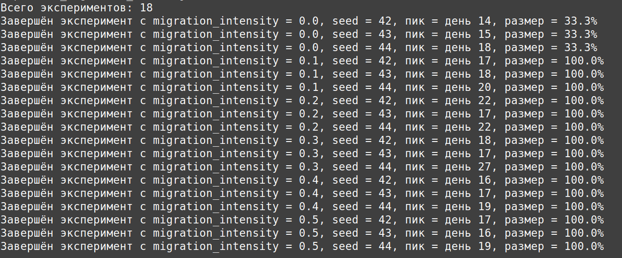

Рисунок 27: интенсивности время до пика

## 4. Миграция

После этого я создала текст на основе литературного кода: чистого кода, записной книжки jupyter и документации в формате Quarto. Я запускала все ячейки в файле jupyter notebook, и все работает хорошо(рис.27)

[figure not shown]

Рисунок 28: создание файлов

## 5. Карантинные меры

Я модифицирую модель, добавляя возможность закрытия города (сброса миграции из него) при превышении порога заболеваемости(рис.27)

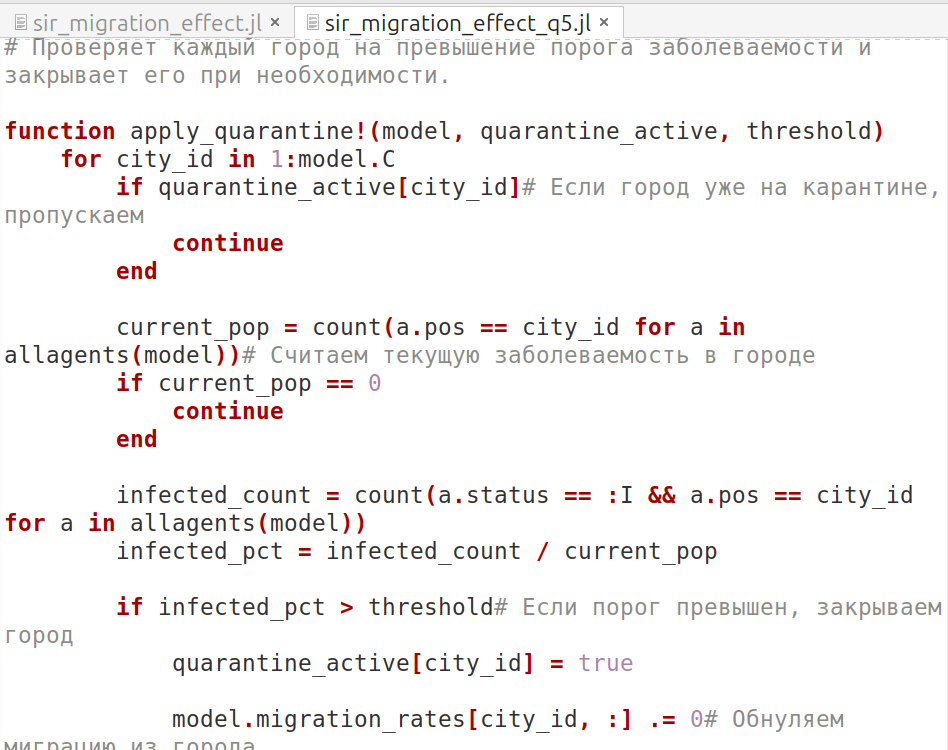

Рисунок 29: Карантинные меры

## 5. Карантинные меры

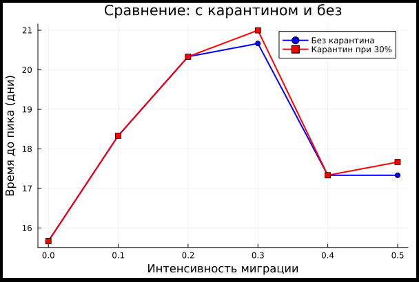

Рисунок 30: Карантинные меры

## 6. Оптимизация

Я создала файл sir_optimize_parameters.jl и копирую в него скрипт из лабораторного руководства. Скрипт Ищет оптимальные комбинации параметров, минимизирующие одновременно два критерия: пиковую заболеваемость и долю умерших. Использует эволюционный алгоритм (Borg MOEA) из пакета BlackBoxOptim.(рис.29)

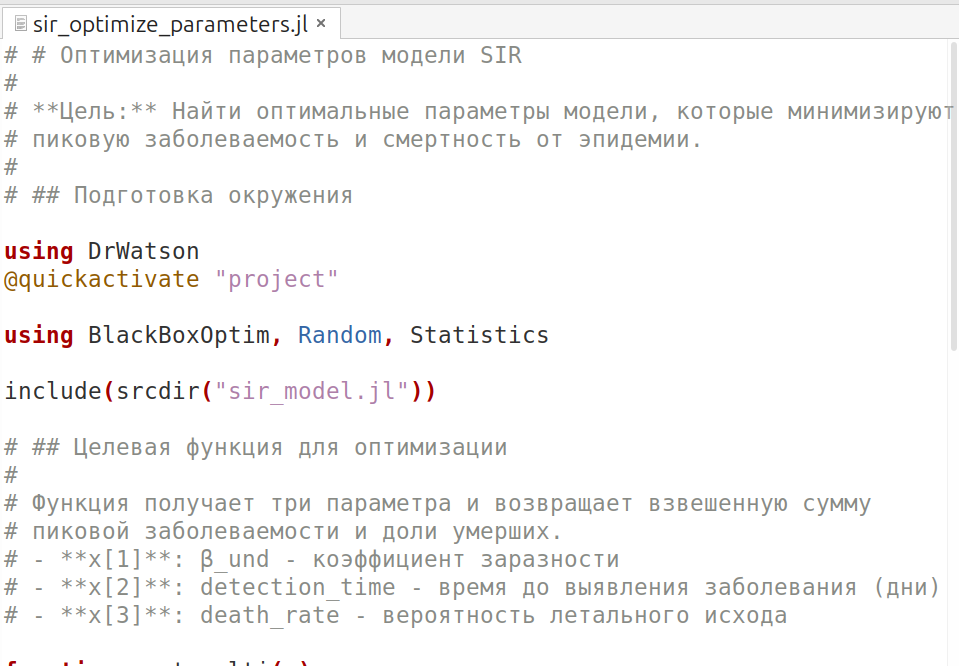

Рисунок 31: оптимизация параметров